# D2SC: Weekly Assignments

Albert Sebastian

2024-11-01

# Initial Loading

```r
library(tidyverse)
library(ggdist)
```

# Weekly Assignment 1

To figure out how to load a package in R, I started by searching for “how to load an R package” in Google. I found several helpful resources, including Stack Overflow and the RStudio website. One useful link was ‘Stack Overflow - How to Load a Package in R’ (https://stackoverflow.com/questions/11805142/how-to-load-a-package-in-r).

I verified that the ‘tidyverse’ package was correctly loaded by running ‘library(tidyverse)’ in the R console and checking that no error messages appeared. I also used the ‘sessionInfo()’ function to confirm that ‘tidyverse’ was listed among the loaded packages.

```r
help(package = "tidyverse")
```

The ‘tidyverse’ is a set of packages that work in harmony because they share common data representations and ‘API’ design. This package is designed to make it easy to install and load multiple ‘tidyverse’ packages in a single step. Learn more about the ‘tidyverse’ at https://www.tidyverse.org.

# Weekly Assignment 2

```r
library(readr)
analogy_data <- read_csv("\\Users\\alber\\Documents\\GitHub\\CogSci412-Data2SciComm\\WeeklyAssignments\\WeeklyAssignments\\tidy_data\\MFIndD_analogy.csv")
analogy_data
```

```
## # A tibble: 792 × 6
##    qualtrics_id    trial_number match_type_0 match_type_1 response response_type
##    <chr>                  <dbl> <chr>        <chr>           <dbl> <chr>
##  1 R_2dlRKzx851f1…            3 Rel          Obj                 1 Obj
##  2 R_2dlRKzx851f1…            4 Rel          Obj                 1 Obj
##  3 R_2dlRKzx851f1…            1 Rel          Obj                 1 Obj
##  4 R_2dlRKzx851f1…            6 Obj          Rel                 0 Obj
##  5 R_2dlRKzx851f1…            5 Obj          Rel                 0 Obj
##  6 R_2dlRKzx851f1…            8 Obj          Rel                 0 Obj
##  7 R_2dlRKzx851f1…            2 Rel          Obj                 1 Obj
##  8 R_2dlRKzx851f1…            7 Obj          Rel                 0 Obj
##  9 R_Qb1tzaskoeU0…            7 Obj          Rel                 0 Obj
## 10 R_Qb1tzaskoeU0…            1 Rel          Obj                 1 Obj
## # ℹ 782 more rows
```

The qualtrics_id column seems to be the unique identifier for each participant

```r
library(dplyr)

dimensions <- dim(analogy_data)
rows <- dimensions[1]
cols <- dimensions[2]
rows
```

```
## [1] 792
```

```r
cols
```

```
## [1] 6
```

2a. There are 792 rows and 6 columns in the dataset. The dim() function was used to retrieve the dimensions of the dataset, specifically the number of rows and columns. By calling dim(analogy_data), it returned a vector where the first element indicated the number of rows and the second element indicated the number of columns.

```r
unique_participants <- analogy_data %>%
  distinct(qualtrics_id) %>%
  count()
unique_participants
```

```
## # A tibble: 1 × 1
##       n
##   <int>
## 1    99
```

There are 99 unique people in the dataset.

```r
trials_per_participant <- analogy_data %>%
  group_by(qualtrics_id) %>%
  summarise(trial_count = n())

consistent_trials <- n_distinct(trials_per_participant$trial_count) == 1
consistent_trials
```

```
## [1] TRUE
```

Everyone has the same number of trials in this dataset

# Weekly Assignment 3

```r
# Attempting to summarize relational matches
summary_data <- analogy_data %>%
  group_by(participant_id) %>%
  summarize(relational_matches = sum(response_type == "Relational", na.rm = TRUE))
```

To fix it, I: 1. Reviewed the dataset to check the exact labels used for the responses. 2. Realized that the correct label was `"Rel"` for relational matches. 3. Updated the code accordingly:

```r
# Summarize the data
summary_data <- analogy_data %>%
  group_by(qualtrics_id) %>%
  summarize(relational_matches = sum(response_type == "Rel", na.rm = TRUE))

# Check the result
head(summary_data)
```

```
## # A tibble: 6 × 2
##   qualtrics_id      relational_matches
##   <chr>                          <int>
## 1 R_0SrX3uRtXaupbhv                  0
## 2 R_0V8O8mrLiHO3Ghj                  8
## 3 R_1BW5H5J1jQFEpuk                  8
## 4 R_1E0SHQwiV6CXRoo                  4
## 5 R_1F9e3CRe4Tb8JhE                  2
## 6 R_1GPuj1DFOUqlnm3                  0
```

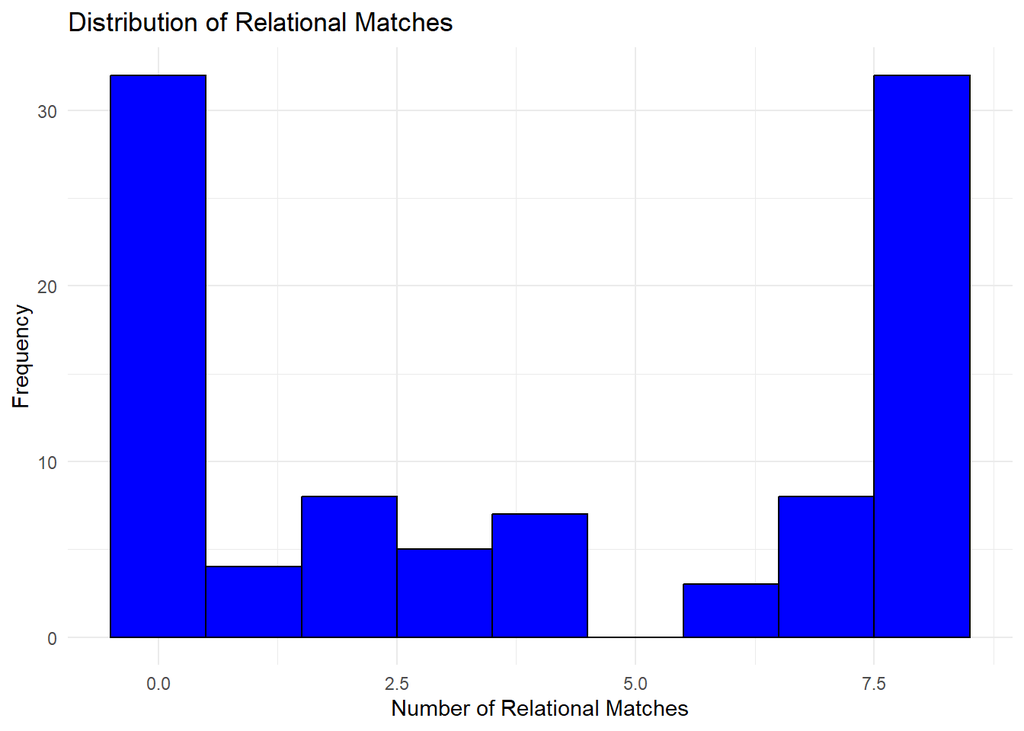

```r
library(ggplot2)

# Create a histogram
ggplot(summary_data, aes(x = relational_matches)) +
  geom_histogram(binwidth = 1, fill = "blue", color = "black") +
  labs(title = "Distribution of Relational Matches",
       x = "Number of Relational Matches",
       y = "Frequency") +
  theme_minimal()
```

```r
# Reshape the data
reshaped_data <- analogy_data %>%
  select(qualtrics_id, trial_number, response_type) %>%
  pivot_wider(names_from = trial_number, values_from = response_type, names_prefix = "Trial_")

# Check the reshaped data
head(reshaped_data)
```

```
## # A tibble: 6 × 9
##   qualtrics_id   Trial_3 Trial_4 Trial_1 Trial_6 Trial_5 Trial_8 Trial_2 Trial_7
##   <chr>          <chr>   <chr>   <chr>   <chr>   <chr>   <chr>   <chr>   <chr>
## 1 R_2dlRKzx851f… Obj     Obj     Obj     Obj     Obj     Obj     Obj     Obj
## 2 R_Qb1tzaskoeU… Obj     Obj     Obj     Obj     Obj     Obj     Obj     Obj
## 3 R_8AGSWBQpPas… Rel     Rel     Rel     Rel     Rel     Obj     Rel     Rel
## 4 R_1Tv8RlXGXRD… Obj     Obj     Obj     Obj     Obj     Obj     Obj     Obj
## 5 R_3p3Glk1o4y2… Obj     Obj     Obj     Obj     Obj     Rel     Obj     Obj
## 6 R_NVYrJklfFqR… Obj     Obj     Obj     Obj     Obj     Obj     Obj     Obj
```

# Weekly Assignment 4

```r
library(dplyr)

data <- read.csv("WeeklyAssignments\\tidy_data\\MFIndD_REI.csv")

# Preview the data
head(data)
```

```
##        qualtrics_id sub_type item_number rev_scoring response scored_response
## 1 R_1lnLF0rQ3biXSbK       RE           1         neg        2               4
## 2 R_1lnLF0rQ3biXSbK       RA           1         neg        4               2
## 3 R_1lnLF0rQ3biXSbK       RE           2        <NA>        3               3
## 4 R_1lnLF0rQ3biXSbK       RA           2         neg        3               3
## 5 R_1lnLF0rQ3biXSbK       RE           3         neg        2               4
## 6 R_1lnLF0rQ3biXSbK       RE           4        <NA>        2               2
```

```r
# Check column types
str(data$response)
```

```
##  chr [1:4000] "2" "4" "3" "3" "2" "2" "2" "2" "2" "2" "4" "4" "3" "3" "4" ...
```

```r
str(data$scored_response)
```

```
##  int [1:4000] 4 2 3 3 4 2 4 4 4 2 ...
```

The “response” column is of type character while the “scored_respose” column is a numeric(int) type.The response column contains the actual survey responses which is not inherently numeric, so it is stored as a character or factor type. The scored_response column contains numeric values that have been derived from the responses, specifically designed to quantify the survey responses for analysis.

```r
# Convert the response column into numeric values
data <- data %>%
  mutate(response_numeric = as.double(case_when(
    response == "Strongly Disagree" ~ 1,
    response == "Disagree" ~ 2,
    response == "Neutral" ~ 3,
    response == "Agree" ~ 4,
    response == "Strongly Agree" ~ 5,
    TRUE ~ NA_real_  # Handling any unexpected values
  )))

data$response_numeric[is.na(data$response_numeric)] <- as.double(data$response[is.na(data$response_numeric)])

head(data)
```

```
##        qualtrics_id sub_type item_number rev_scoring response scored_response
## 1 R_1lnLF0rQ3biXSbK       RE           1         neg        2               4
## 2 R_1lnLF0rQ3biXSbK       RA           1         neg        4               2
## 3 R_1lnLF0rQ3biXSbK       RE           2        <NA>        3               3
## 4 R_1lnLF0rQ3biXSbK       RA           2         neg        3               3
## 5 R_1lnLF0rQ3biXSbK       RE           3         neg        2               4
## 6 R_1lnLF0rQ3biXSbK       RE           4        <NA>        2               2
##   response_numeric
## 1                2
## 2                4
## 3                3
## 4                3
## 5                2
## 6                2
```

```r
data <- data %>%
  mutate(new_scored_response = case_when(
    is.na(rev_scoring) ~ response_numeric,
    TRUE ~ 6 - response_numeric  # Reverse scoring logic
  ))

head(data)
```

```
##        qualtrics_id sub_type item_number rev_scoring response scored_response
## 1 R_1lnLF0rQ3biXSbK       RE           1         neg        2               4
## 2 R_1lnLF0rQ3biXSbK       RA           1         neg        4               2
## 3 R_1lnLF0rQ3biXSbK       RE           2        <NA>        3               3
## 4 R_1lnLF0rQ3biXSbK       RA           2         neg        3               3
## 5 R_1lnLF0rQ3biXSbK       RE           3         neg        2               4
## 6 R_1lnLF0rQ3biXSbK       RE           4        <NA>        2               2
##   response_numeric new_scored_response
## 1                2                   4
## 2                4                   2
## 3                3                   3
## 4                3                   3
## 5                2                   4
## 6                2                   2
```

```r
# Compare new_scored_response with scored_response
comparison <- data %>%
  select(new_scored_response, scored_response) %>%
  mutate(match = new_scored_response == scored_response)

# Summary of matches
match_summary <- comparison %>%
  summarise(
    total_rows = n(),
    matches = sum(match, na.rm = TRUE),
    mismatch_count = total_rows - matches
  )

print(match_summary)
```

```
##   total_rows matches mismatch_count
## 1       4000    3986             14
```

# Weekly Assignment 5

```r
library(dplyr)
library(readr)

# Read the dataset
data <- read_csv("WeeklyAssignments/tidy_data/MFIndD_REI.csv")
# Create a new column for reverse scoring
data <- data %>%
  mutate(new_scored_response = case_when(
    is.na(rev_scoring) ~ scored_response,
    TRUE ~ 6 - scored_response  # Reverse scoring logic
  ))

# Summarize the data to get one row per participant and sub_scale
summary_data2 <- data %>%
  group_by(qualtrics_id, sub_type) %>%  # Group by participant and sub_scale
  summarise(score = sum(new_scored_response, na.rm = TRUE), .groups = 'drop')

# Preview the summarized data
print(head(summary_data2))
```

```
## # A tibble: 6 × 3
##   qualtrics_id      sub_type score
##   <chr>             <chr>    <dbl>
## 1 R_0SrX3uRtXaupbhv EA          23
## 2 R_0SrX3uRtXaupbhv EE          25
## 3 R_0SrX3uRtXaupbhv RA          22
## 4 R_0SrX3uRtXaupbhv RE          27
## 5 R_0V8O8mrLiHO3Ghj EA          24
## 6 R_0V8O8mrLiHO3Ghj EE          30
```

```r
# Check for NA scores in the summarized data
na_scores <- summary_data2 %>%
  filter(is.na(score))

# Count the number of NA scores
na_count <- nrow(na_scores)

# Output the count of NA scores
na_count
```

```
## [1] 0
```

The code filters the summary_data for any rows where the score is NA and counts how many such rows exist. Since na_count returns 0, there are no NA scores in the summary.

```r
# Summarize the analogy dataset
analogy_summary <- analogy_data %>%
  group_by(qualtrics_id) %>%
  summarize(relational_matches = sum(response_type == "Rel", na.rm = TRUE), .groups = 'drop')

# Combine the two summarized datasets
combined_data <- full_join(summary_data2, analogy_summary, by = "qualtrics_id")

# Preview the combined dataset
print(head(combined_data))
```

```
## # A tibble: 6 × 4
##   qualtrics_id      sub_type score relational_matches
##   <chr>             <chr>    <dbl>              <int>
## 1 R_0SrX3uRtXaupbhv EA          23                  0
## 2 R_0SrX3uRtXaupbhv EE          25                  0
## 3 R_0SrX3uRtXaupbhv RA          22                  0
## 4 R_0SrX3uRtXaupbhv RE          27                  0
## 5 R_0V8O8mrLiHO3Ghj EA          24                  8
## 6 R_0V8O8mrLiHO3Ghj EE          30                  8
```

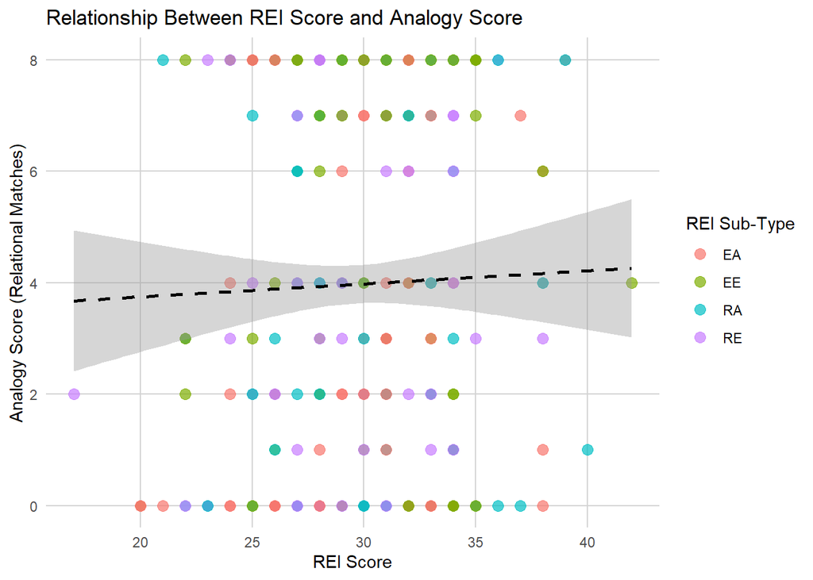

```r
library(ggplot2)

# Create the scatterplot
ggplot(combined_data, aes(x = score, y = relational_matches, color = sub_type)) +
  geom_point(size = 3, alpha = 0.7) +  # Scatter points
  geom_smooth(method = "lm", se = TRUE, linetype = "dashed", color = "black") +  # Smoothed line
  labs(title = "Relationship Between REI Score and Analogy Score",
       x = "REI Score",
       y = "Analogy Score (Relational Matches)",
       color = "REI Sub-Type") +  # Custom axis labels
  theme_minimal() +  # Clean theme
  theme(panel.grid.major = element_line(color = "lightgray"),  # Change grid line color
        panel.grid.minor = element_blank())  # Remove minor grid lines
```

# Weekly Assignment 6

```r
data <- read_csv("WeeklyAssignments/tidy_data/MFIndD_probtask.csv")
# Get distinct values in the 'condition' column
distinct_conditions_vector <- unique(data$condition)

# Initialize an empty vector for mean reaction times
mean_reaction_times <- numeric(length(distinct_conditions_vector))

# Loop through each distinct condition
for (i in seq_along(distinct_conditions_vector)) {
    condition <- distinct_conditions_vector[i]
    conditionstr=condition
    # Filter the data
    condition_data <- subset(data, data$condition == conditionstr)
    # Calculate the mean reaction time
    mean_rt <- mean(condition_data$rt, na.rm = TRUE)
    mean_reaction_times[i] <- mean_rt

    # Print the mean reaction time for each condition
    print(paste("Condition:", condition, "Mean RT:", mean_rt))
}
```

```
## [1] "Condition: dots_EqSizeSep Mean RT: 889.820191713049"
## [1] "Condition: dots_EqSizeRand Mean RT: 879.618429189858"
## [1] "Condition: blob_shifted Mean RT: 892.285454545455"
## [1] "Condition: blob_stacked Mean RT: 847.515303030303"
```

```r
results <- data.frame(Condition = distinct_conditions_vector, Mean_Reaction_Time = mean_reaction_times)

print(results)
```

```
##         Condition Mean_Reaction_Time
## 1  dots_EqSizeSep           889.8202
## 2 dots_EqSizeRand           879.6184
## 3    blob_shifted           892.2855
## 4    blob_stacked           847.5153
```

```r
# Using dplyr with across()
results_across <- data %>%
  group_by(condition) %>%
  summarize(
    Mean_Reaction_Time = mean(rt, na.rm = TRUE),
    Overall_Accuracy = mean(correct, na.rm = TRUE),
    .groups = 'drop'
  )

print(results_across)
```

```
## # A tibble: 4 × 3
##   condition       Mean_Reaction_Time Overall_Accuracy
##   <chr>                        <dbl>            <dbl>
## 1 blob_shifted                  892.            0.620
## 2 blob_stacked                  848.            0.697
## 3 dots_EqSizeRand               880.            0.687
## 4 dots_EqSizeSep                890.            0.618
```

```r
# Using dplyr without across()
results_no_across <- data %>%
  group_by(condition) %>%
  summarize(
    Mean_Reaction_Time = mean(rt, na.rm = TRUE),
    Overall_Accuracy = mean(correct, na.rm = TRUE),
    .groups = 'drop'
  )

print(results_no_across)
```

```
## # A tibble: 4 × 3
##   condition       Mean_Reaction_Time Overall_Accuracy
##   <chr>                        <dbl>            <dbl>
## 1 blob_shifted                  892.            0.620
## 2 blob_stacked                  848.            0.697
## 3 dots_EqSizeRand               880.            0.687
## 4 dots_EqSizeSep                890.            0.618
```

# Weekly Assignment 7

```r
prob_data <- read_csv("WeeklyAssignments/tidy_data/MFIndD_probtask.csv")
```

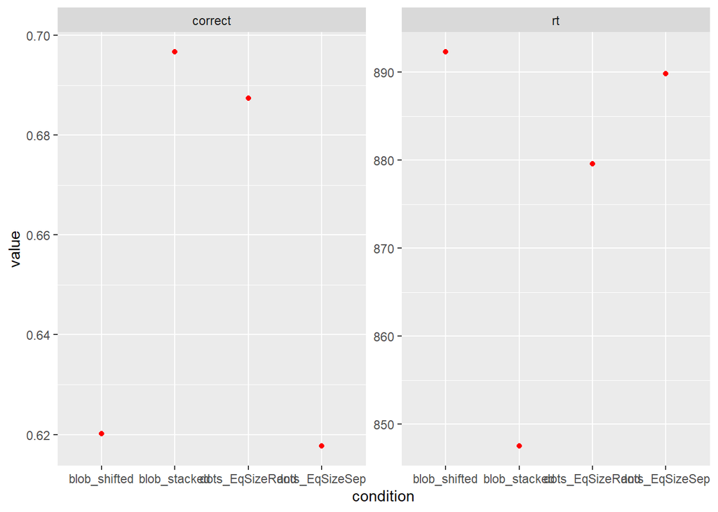

```r
prob_data %>%
group_by(condition) %>%
summarise(across(c(rt, correct), mean)) %>%
pivot_longer(c(rt, correct)) %>%
ggplot(aes(y = value, x = condition)) +
geom_point(color = "red") +
facet_wrap(~name, scales = "free")
```

1a. Based on the plot, people’s scores and reaction times are inversely related- with the higher reaction times having a lower score and vice versa. The dots_EqSizeRand image represented this relationship the least.

1b. The first thing I noticed when I looked at the plot was that the data points for 3 of the 4 images were on completely different ends of the y axis when comparing the correctness graph and the reaction time graph. I think this is the case because the longer you take to come up with an answer, the more unsure you are of what the correct answer is. When your able to answer a question quickly, particularly in this sort of task, your level of certainty is generally higher.

1c. The information that is hard to see in this plot is the inverse relation between the people’s score and reaction time for the dots_EqSizeRand image- especially when compared to the relations between the two for the other images. I think this is the case because if the relationship between reaction time and correctness followed the same pattern as the other images, this image’s reaction time would be a lot less compared to where it is now. I believe this is because it is easier to be correct when the blue and orange points are not separated which is why blob_stacked and dots_EqSizeRand have the highest scores- but the latter takes much more time because there are significantly more data points to account for.

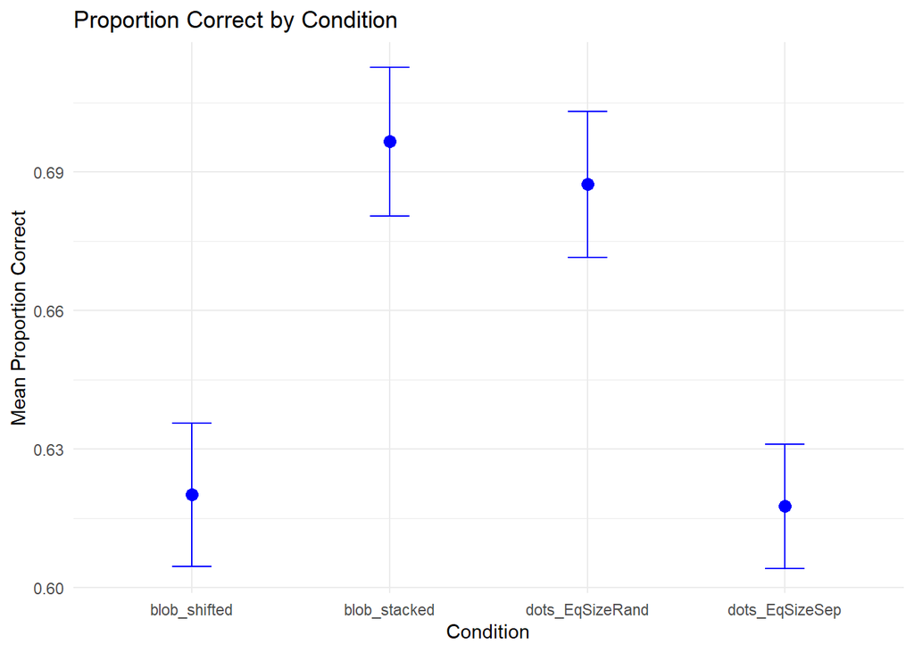

```r
summarized_data <- prob_data %>%
  group_by(SubID, condition) %>%
  summarise(prop_corr = mean(correct), .groups = "drop")

# Calculate mean and standard error of proportion correct for each condition
plot_data <- summarized_data %>%
  group_by(condition) %>%
  summarise(
    mean_prop_corr = mean(prop_corr),
    se_prop_corr = sd(prop_corr) / sqrt(n())
  )

# Create a plot with error bars to represent standard error
ggplot(plot_data, aes(x = condition, y = mean_prop_corr)) +
  geom_point(color = "blue", size = 3) +
  geom_errorbar(aes(ymin = mean_prop_corr - se_prop_corr, ymax = mean_prop_corr + se_prop_corr),
                width = 0.2, color = "blue") +
  labs(x = "Condition", y = "Mean Proportion Correct", title = "Proportion Correct by Condition") +
  theme_minimal()
```

Instead of simply plotting mean values, we calculate prop_corr to represent the proportion of correct trials per participant and condition, which better captures individual performance. Also, adding error bars to the mean proportions conveys the variability in the data, giving viewers a clearer sense of how consistent the accuracy is across participants. This avoids the common issue of plots that misleadingly imply small differences are meaningful without considering variability.

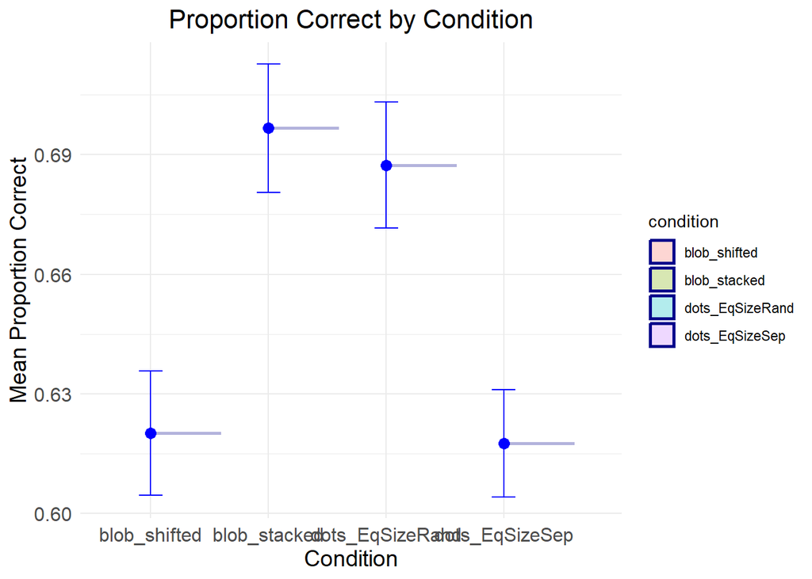

```r
summarized_data <- prob_data %>%
  group_by(SubID, condition) %>%
  summarise(prop_corr = mean(correct), .groups = "drop")


plot_data <- summarized_data %>%
  group_by(condition) %>%
  summarise(
    mean_prop_corr = mean(prop_corr),
    se_prop_corr = sd(prop_corr) / sqrt(n())
  )

ggplot(plot_data, aes(x = condition, y = mean_prop_corr)) +
  # Add slab interval to show the distribution of data
  stat_slab(
    aes(fill = condition), color = "darkblue", alpha = 0.3, scale = 0.6
  ) +
  geom_point(color = "blue", size = 3) +
  geom_errorbar(aes(ymin = mean_prop_corr - se_prop_corr, ymax = mean_prop_corr + se_prop_corr),
                width = 0.2, color = "blue") +
  labs(x = "Condition", y = "Mean Proportion Correct", title = "Proportion Correct by Condition") +
  theme_minimal() +
  # Center title and increase text size for readability
  theme(
    plot.title = element_text(hjust = 0.5, size = 16),
    axis.title = element_text(size = 14),
    axis.text = element_text(size = 12)
  )
```

# Weekly Assignment 8

```r
summary_data <- prob_data %>%
  group_by(SubID, condition) %>%
  summarise(
    rt = mean(rt, na.rm = TRUE),
    correct = mean(correct, na.rm = TRUE)
  ) %>%
  ungroup()
# View the first six rows
print(summary_data %>% slice(1:6))
```

```
## # A tibble: 6 × 4
##   SubID             condition          rt correct
##   <chr>             <chr>           <dbl>   <dbl>
## 1 R_0SrX3uRtXaupbhv dots_EqSizeRand 1030.   0.470
## 2 R_0SrX3uRtXaupbhv dots_EqSizeSep   986.   0.667
## 3 R_0V8O8mrLiHO3Ghj blob_shifted     742.   0.470
## 4 R_0V8O8mrLiHO3Ghj blob_stacked     920.   0.705
## 5 R_1BW5H5J1jQFEpuk blob_shifted     824.   0.530
## 6 R_1BW5H5J1jQFEpuk blob_stacked     875.   0.705
```

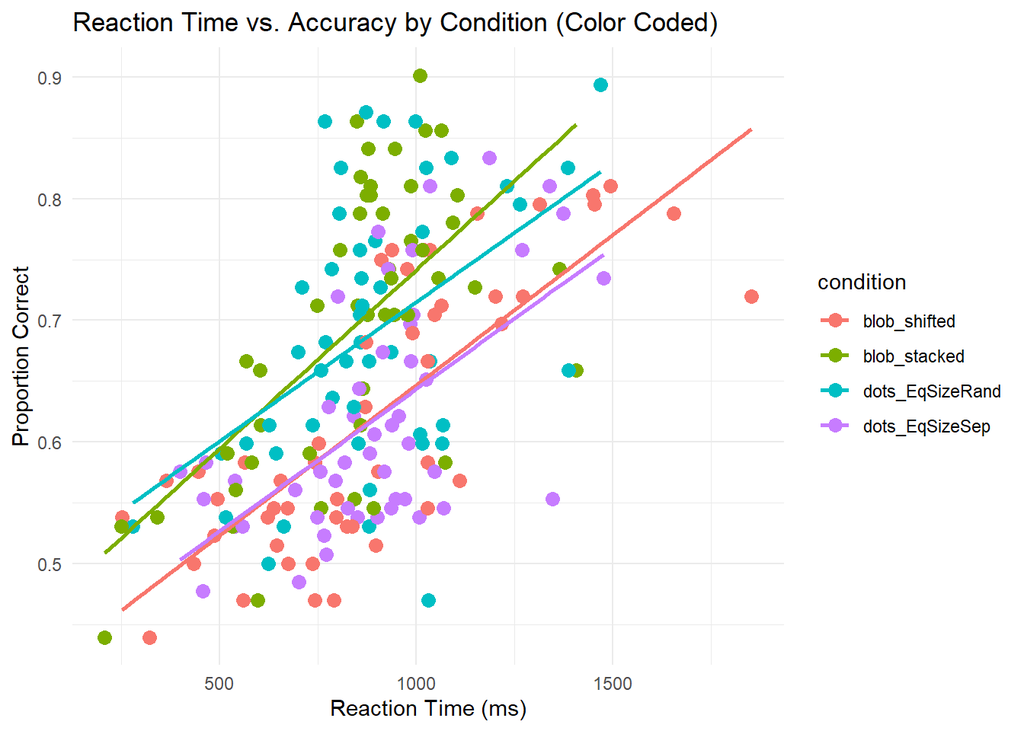

```r
ggplot(summary_data, aes(x = rt, y = correct, color = condition)) +
  geom_point(size = 3) +
  geom_smooth(method = "lm", se = FALSE) +
  labs(
    title = "Reaction Time vs. Accuracy by Condition (Color Coded)",
    x = "Reaction Time (ms)",
    y = "Proportion Correct"
  ) +
  theme_minimal() +
  theme(legend.position = "right")
```

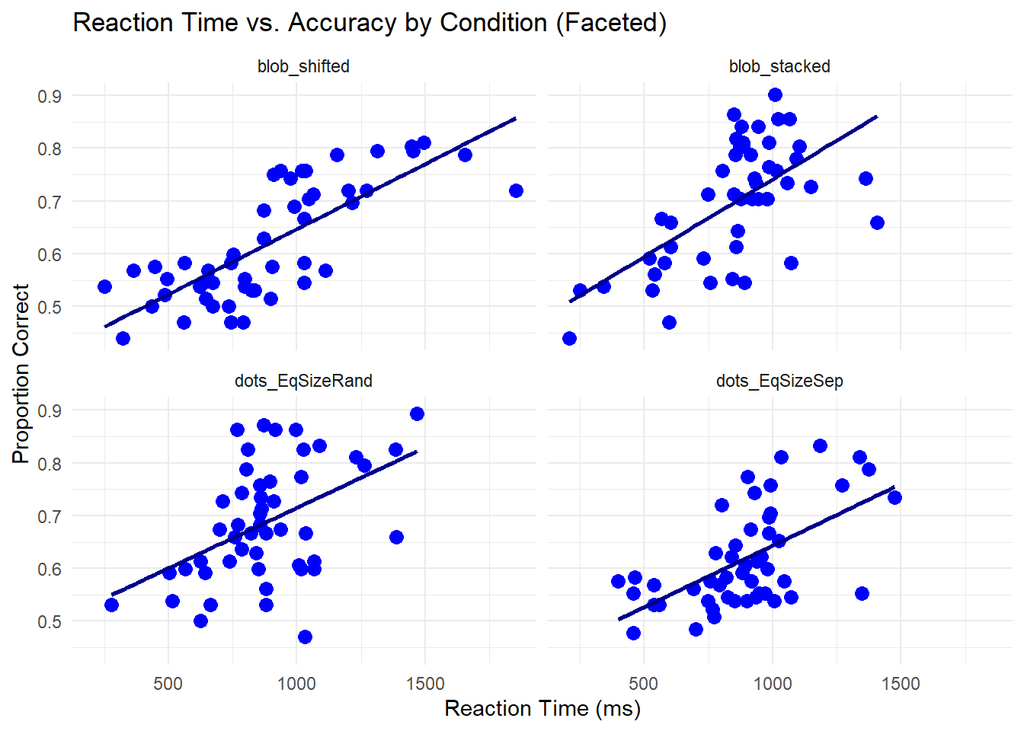

```r
ggplot(summary_data, aes(x = rt, y = correct)) +
  geom_point(size = 3, color = "blue") +
  geom_smooth(method = "lm", se = FALSE, color = "darkblue") +
  labs(
    title = "Reaction Time vs. Accuracy by Condition (Faceted)",
    x = "Reaction Time (ms)",
    y = "Proportion Correct"
  ) +
  facet_wrap(~ condition) +
  theme_minimal()
```

*Observation: Generally speaking, for all conditions, as reaction time increases, accuracy increases as well*